# Roy Kent F**k count

Author

Federico Alegría

# Tidy Tuesday `2023_39`

For Tidy Tuesday’s `2023_39` data, the idea that characters get influenced by their context as they develop throughout a story was non-parametricaly explored (Campbell, 2008; Greimas, 1983). While both authors analysed this narrative resource, Greimas focused on the relationships between characters, and Campbell examined their journey and archetypal patterns.

## Data

> For Deepsha Menghani’s talk on [Data Viz animation and interactivity in Quarto](https://deepshamenghani.github.io/posit_plotly_crosstalk/#/title-slide), she watched each episode of Ted Lasso at 2X speed and diligently noted down every F*bomb and gesture reference, and then made it into the [richmondway R package](https://github.com/deepshamenghani/richmondway)!

> **What is Ted Lasso and who is Roy Kent?**

> [Ted Lasso](https://en.wikipedia.org/wiki/Ted_Lasso) is a TV show that “follows Ted Lasso, an American college football coach who is hired to coach an English soccer team with the secret intention that his inexperience will lead it to failure, but whose folksy, optimistic leadership proves unexpectedly successful. [Roy Kent](https://ted-lasso.fandom.com/wiki/Roy_Kent) is one of the main characters who goes from captain of AFC Richmond to one of the coaches. Particularly in early seasons, he’s a man of few words, but many of them are f**k, expressed in various moods - mad, sad, happy, amused, loving, surprised, thoughtful, and joyous. This dataset includes the number, percentage, and context of f**k used in the show for each episode.

Table 1: Data from the {richmondway} Package

| character | episode_order | season | episode | season_episode | f_count_rk | f_count_total | cum_rk_season | cum_total_season | cum_rk_overall | cum_total_overall | f_score | f_perc | dating_flag | coaching_flag | imdb_rating |
| --- | --- | --- | --- | --- | --- | --- | --- | --- | --- | --- | --- | --- | --- | --- | --- |
| Roy Kent | 1 | 1 | 1 | S1_e1 | 2 | 13 | 2 | 13 | 2 | 13 | 0.15 | 15.4 | No | No | 7.8 |
| Roy Kent | 2 | 1 | 2 | S1_e2 | 2 | 8 | 4 | 21 | 4 | 21 | 0.25 | 25.0 | No | No | 8.1 |
| Roy Kent | 3 | 1 | 3 | S1_e3 | 7 | 13 | 11 | 34 | 11 | 34 | 0.54 | 53.8 | No | No | 8.5 |
| Roy Kent | 4 | 1 | 4 | S1_e4 | 8 | 17 | 19 | 51 | 19 | 51 | 0.47 | 47.1 | No | No | 8.2 |
| Roy Kent | 5 | 1 | 5 | S1_e5 | 4 | 13 | 23 | 64 | 23 | 64 | 0.31 | 30.8 | No | No | 8.9 |
| Roy Kent | 6 | 1 | 6 | S1_e6 | 2 | 9 | 25 | 73 | 25 | 73 | 0.22 | 22.2 | No | No | 8.5 |
| Roy Kent | 7 | 1 | 7 | S1_e7 | 5 | 15 | 30 | 88 | 30 | 88 | 0.33 | 33.3 | No | No | 9.0 |
| Roy Kent | 8 | 1 | 8 | S1_e8 | 7 | 18 | 37 | 106 | 37 | 106 | 0.39 | 38.9 | Yes | No | 8.7 |
| Roy Kent | 9 | 1 | 9 | S1_e9 | 14 | 22 | 51 | 128 | 51 | 128 | 0.64 | 63.6 | Yes | No | 8.6 |
| Roy Kent | 10 | 1 | 10 | S1_e10 | 5 | 22 | 56 | 150 | 56 | 150 | 0.23 | 22.7 | Yes | No | 9.1 |
| Roy Kent | 11 | 2 | 1 | S2_e1 | 11 | 16 | 11 | 16 | 67 | 166 | 0.69 | 68.8 | Yes | No | 7.6 |
| Roy Kent | 12 | 2 | 2 | S2_e2 | 10 | 22 | 21 | 38 | 77 | 188 | 0.45 | 45.5 | Yes | No | 8.0 |
| Roy Kent | 13 | 2 | 3 | S2_e3 | 2 | 8 | 23 | 46 | 79 | 196 | 0.25 | 25.0 | Yes | No | 8.4 |
| Roy Kent | 14 | 2 | 4 | S2_e4 | 2 | 6 | 25 | 52 | 81 | 202 | 0.33 | 33.3 | Yes | No | 8.6 |
| Roy Kent | 15 | 2 | 5 | S2_e5 | 23 | 32 | 48 | 84 | 104 | 234 | 0.72 | 71.9 | Yes | Yes | 8.9 |
| Roy Kent | 16 | 2 | 6 | S2_e6 | 12 | 18 | 60 | 102 | 116 | 252 | 0.67 | 66.7 | Yes | Yes | 8.6 |
| Roy Kent | 17 | 2 | 7 | S2_e7 | 6 | 15 | 66 | 117 | 122 | 267 | 0.40 | 40.0 | Yes | Yes | 7.7 |
| Roy Kent | 18 | 2 | 8 | S2_e8 | 5 | 17 | 71 | 134 | 127 | 284 | 0.29 | 29.4 | Yes | Yes | 9.0 |
| Roy Kent | 19 | 2 | 9 | S2_e9 | 3 | 12 | 74 | 146 | 130 | 296 | 0.25 | 25.0 | Yes | Yes | 6.8 |
| Roy Kent | 20 | 2 | 10 | S2_e10 | 4 | 13 | 78 | 159 | 134 | 309 | 0.31 | 30.8 | Yes | Yes | 8.5 |
| Roy Kent | 21 | 2 | 11 | S2_e11 | 5 | 12 | 83 | 171 | 139 | 321 | 0.42 | 41.7 | Yes | Yes | 8.2 |
| Roy Kent | 22 | 2 | 12 | S2_e12 | 23 | 44 | 106 | 215 | 162 | 365 | 0.52 | 52.3 | Yes | Yes | 8.8 |
| Roy Kent | 23 | 3 | 1 | S3_e1 | 6 | 17 | 6 | 17 | 168 | 382 | 0.35 | 35.3 | No | Yes | 7.7 |
| Roy Kent | 24 | 3 | 2 | S3_e2 | 16 | 31 | 22 | 48 | 184 | 413 | 0.52 | 51.6 | No | Yes | 8.3 |
| Roy Kent | 25 | 3 | 3 | S3_e3 | 10 | 25 | 32 | 73 | 194 | 438 | 0.40 | 40.0 | No | Yes | 7.9 |
| Roy Kent | 26 | 3 | 4 | S3_e4 | 17 | 42 | 49 | 115 | 211 | 480 | 0.40 | 40.5 | No | Yes | 8.2 |
| Roy Kent | 27 | 3 | 5 | S3_e5 | 13 | 36 | 62 | 151 | 224 | 516 | 0.36 | 36.1 | No | Yes | 7.1 |
| Roy Kent | 28 | 3 | 6 | S3_e6 | 13 | 21 | 75 | 172 | 237 | 537 | 0.62 | 61.9 | No | Yes | 9.0 |
| Roy Kent | 29 | 3 | 7 | S3_e7 | 10 | 30 | 85 | 202 | 247 | 567 | 0.33 | 33.3 | No | Yes | 8.3 |
| Roy Kent | 30 | 3 | 8 | S3_e8 | 6 | 26 | 91 | 228 | 253 | 593 | 0.23 | 23.1 | No | Yes | 6.6 |
| Roy Kent | 31 | 3 | 9 | S3_e9 | 13 | 46 | 104 | 274 | 266 | 639 | 0.28 | 28.3 | No | Yes | 8.5 |
| Roy Kent | 32 | 3 | 10 | S3_e10 | 10 | 18 | 114 | 292 | 276 | 657 | 0.56 | 55.6 | No | Yes | 8.5 |
| Roy Kent | 33 | 3 | 11 | S3_e11 | 13 | 46 | 127 | 338 | 289 | 703 | 0.28 | 28.3 | No | Yes | 9.3 |
| Roy Kent | 34 | 3 | 12 | S3_e12 | 11 | 39 | 138 | 377 | 300 | 742 | 0.28 | 28.2 | No | Yes | 9.4 |

## Explore

Let’s explore the notion that fictional characters behave in line with their surroundings:

### Check for Normality

- H0: data follows a normal distribution
- H1: data not follows a normal distribution

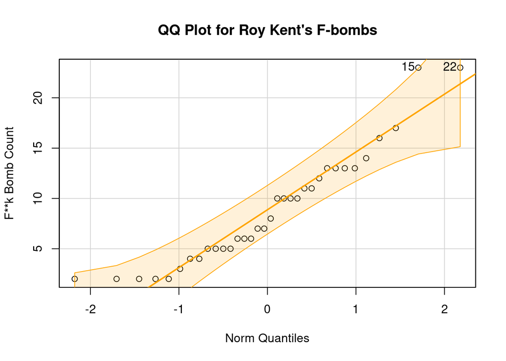

```
[1] 15 22
```

```
    Shapiro-Wilk normality test

data:  richmondway$f_count_rk
W = 0.91593, p-value = 0.01242
```

## Analyse

### F**k Bombs according to Dating Status

| dating_flag | mean | median | min | max | range | n |
| --- | --- | --- | --- | --- | --- | --- |
| No | 8.84 | 10 | 2 | 17 | 7.5 | 19 |
| Yes | 8.80 | 6 | 2 | 23 | 7.0 | 15 |

**Testing the measured difference**

$$H0: Mdn1 = Mdn2$$

$$H1: Mdn1 ≠ Mdn2$$

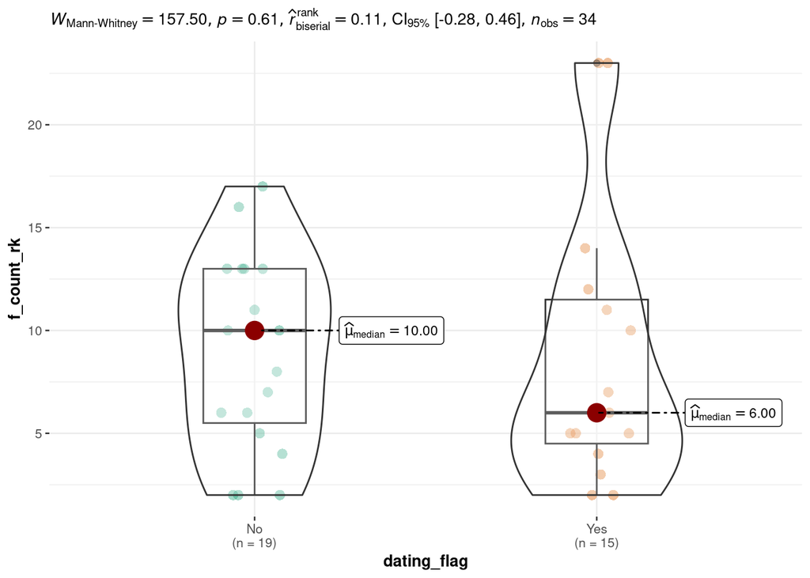

```
    Wilcoxon rank sum test

data:  f_count_rk by dating_flag
W = 157.5, p-value = 0.6013
alternative hypothesis: true location shift is not equal to 0
95 percent confidence interval:
 -3.000022  4.999973
sample estimates:
difference in location
             0.9999715
```

The output from the `stats::wilcox.test()` function is W = 157.5 with a p-value = 0.6013, which is greater than the established threshold of 0.05. Therefore, the null hypothesis is not rejected in favor of the alternative hypothesis; meaning there’s no significant difference between the two groups being compared at the 5% significance level.

### F**k Bombs according to Coaching Status

| coaching_flag | mean | median | min | max | range | n |
| --- | --- | --- | --- | --- | --- | --- |
| No | 5.79 | 5.0 | 2 | 14 | 5.75 | 14 |
| Yes | 10.95 | 10.5 | 3 | 23 | 7.00 | 20 |

**Testing the measured difference**

$$H0: Mdn1 = Mdn2$$
$$H1: Mdn1 ≠ Mdn2$$

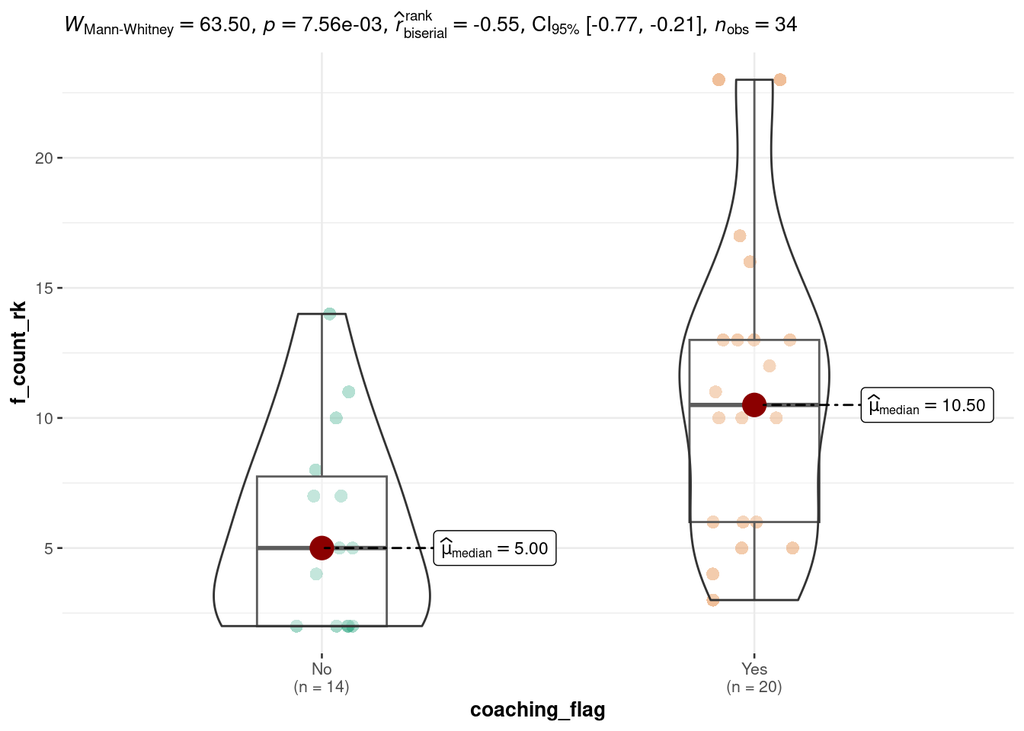

[output not shown]

### F**k Bombs according to Season Count

| season | mean | median | min | max | range | n |
| --- | --- | --- | --- | --- | --- | --- |
| 1 | 5.60 | 5.0 | 2 | 14 | 4.5 | 10 |
| 2 | 8.83 | 5.5 | 2 | 23 | 7.5 | 12 |
| 3 | 11.50 | 12.0 | 6 | 17 | 3.0 | 12 |

**Testing the measured difference**

$$H0: μ1 = μ2 = μ3 … = μk$$

$$H1: μ1 ≠ μ2 | μ1 ≠ μ3 | … | μk-1 ≠ μk$$

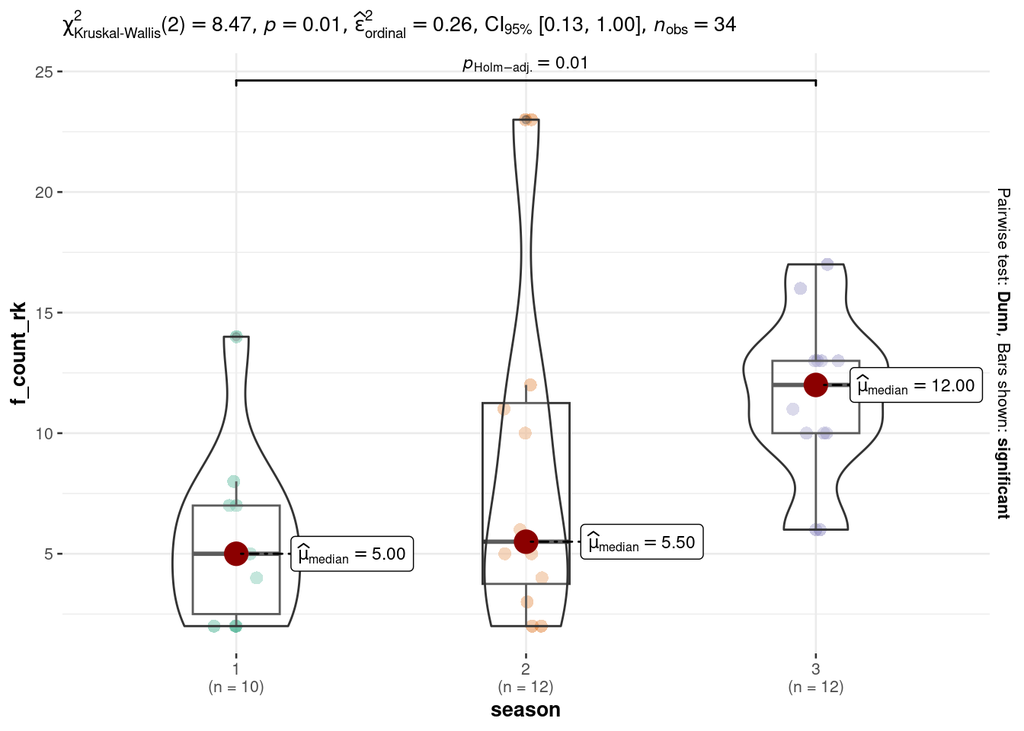

```
    Kruskal-Wallis rank sum test

data:  richmondway$f_count_rk and richmondway$season
Kruskal-Wallis chi-squared = 8.4674, df = 2, p-value = 0.0145
```

The output from the `stats::kruskal.test()` function is is a chi-squared value of 8.4674 with 2 degrees of freedom and a p-value = 0.0145; less than the established threshold of 0.05. Therefore, the null hypothesis can rejected in favor of the alternative hypothesis; and conclude that there is a significant difference between between the groups being compared. Furthermore, the Epsilon-squared shows a large effect size (Field, 2013).

## References

- Campbell, J. (2008). *The hero with a thousand faces* (3rd ed). New World Library.
- Field, A. (2013). *Discovering statistics using IBM SPSS Statistics*. 4th Ed. Sage:London.
- Greimas, A. J. (1983). *Structural semantics: An attempt at a method*. University of Nebraska Press.
- Lovakov, A., & Agadullina, E. (2021). Empirically derived guidelines for effect size interpretation in social psychology. *European Journal of Social Psychology*, *51*(3), 485–504.